# Variation

J. Ignacio Lucas Lledó

3/7/2020

```r
knitr::opts_chunk$set(echo = TRUE)
library(DESeq2)
library(ggplot2)
library(vegan)
library(PoiClaClu)

COUNTS <- '../2019-03-29/genes.PostCount.txt'
```

The counts of reads overlapping a gene in a sample of dormant eggs is determined by the sequencing effort (library size) and the unobserved true proportion of that gene’s transcripts in the set of dormant eggs. In turn, that unobserved proportion is the average of all individual cells in all eggs in the sample. The variance of the sample-wise unobserved proportion of a gene’s transcripts can be thought of as the variance of the average of all cell-wise unobserved proportions. That is, the biological variation between two replicates is made up of the variation in their cells, of course. The sample-wise variance is the variance of an average, which is proportional to the variances and covariances of the cell-wise values.

When performing RNA-seq experiments on anything other than single cells, positive correlations are implicitly assumed: two cells may be expected to have correlated expressions of a gene for being part of the same tissue, the same organism, or for being under similar conditions. The experiment would not make sense if samples were composed of cells with perfect negative correlations, in a way that gene expression changes in, say, half the cells were compensated by changes in the opposite direction in the other half of cells. In such an scenario, any two samples would look alike, despite wide variation at the cell level. Actually, even at the cell level they would look alike, unless cells could be enumerated or classified to be compared between samples.

Thus, it is perfectly reasonable to expect that if an environment makes the expression of a gene more variable among cells (or eggs) it will also make the sample-wise proportion of that gene’s transcript more variable among samples.

Packages like `edgeR` and `DESeq2` that test for differences of gene expression between conditions need to estimate the variance of read counts from few replicates. They share information among genes to compensate for the scarcity of replicates, assuming that genes with similar expression levels must have similar amounts of variation among replicates. In order to obtain estimates of variance for individual values of read counts, they use the observed relationship between dispersion and mean value. In (Anders and Huber 2010) it is quite clear that DESeq2 estimates variance of individual values separately for the different groups of samples. It is less clear that `edgeR` allows for a different variance in different conditions. That would explain why the mean-variance relationship changes so much when estimating variance separately for the two regimes when using `edgeR` (see `2020-01-28`). Here I will use DESeq2 to compare the the variance of gene expression between conditions. I found [This](https://bioconductor.org/packages/release/workflows/vignettes/rnaseqGene/inst/doc/rnaseqGene.html#sample-distances) interesting tutorial.

```r
counts <- as.matrix(read.table(COUNTS, row.names=1, header=TRUE))
samples <- data.frame(row.names = c("X1A_S8", "X1C_S1", "X2A_S7", "X2C_S5",
                                    "X3A_S9", "X3C_S11", "X4A_S6", "X4C_S12",
                                    "X5A_S2", "X5C_S4", "X6A_S3", "X6C_S10"),
                      regime = c("unpredictable", "unpredictable", "unpredictable",
                                 "unpredictable", "predictable", "predictable",
                                 "unpredictable", "unpredictable", "predictable",
                                 "predictable", "predictable", "predictable"),
                      population = c("1", "1", "2", "2", "3", "3",
                                     "4", "4", "5", "5", "6", "6"),
                      treatment = rep(c("hatch", "diapause"), 6))
stopifnot(all.equal(rownames(samples), colnames(counts)))
dds <- DESeqDataSetFromMatrix(countData = round(counts), colData = samples, design = ~ regime)
keep <- rowSums(counts(dds)) > 1
dds <- dds[keep,]
nrow(dds)
```

```
## [1] 30764
```

# Estimating dispersions with DESeq2

```r
dds <- estimateSizeFactors(dds)
dds <- estimateDispersions(dds, fitType = 'parametric')
```

The `estimateDispersions()` function estimates dispersions by maximization of a Cox Reid-adjusted profile likelihood, which is a penalized likelihood that accounts for the usage of data to estimate both the dispersion and the coefficients of the GLM of the expression levels themselves. That is, the design formula is used in the estimation of gene-wise dispersions. But the estimated dispersions are not separate for separate conditions. The model assumes a gene’s expression has the same coefficient of variation in all sample groups. This is described in (McCarthy, Chen, and Smyth 2012). Thus, it does not help compare the dispersions among sample groups.

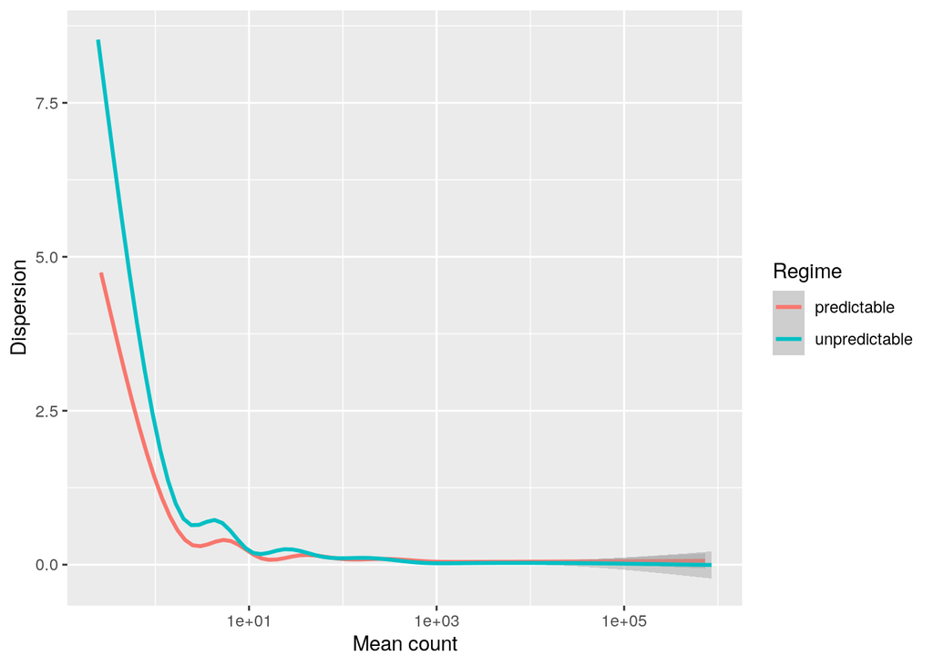

```r
is.random   <- samples$regime == 'unpredictable'
is.regular  <- samples$regime == 'predictable'
dds.random  <- DESeqDataSetFromMatrix(countData = round(counts[, is.random]),
                                      colData = samples[is.random,], design = ~ 1)
dds.regular <- DESeqDataSetFromMatrix(countData = round(counts[, is.regular]),
                                      colData = samples[is.regular,], design = ~ 1)
keep <- rowSums(counts(dds.random)) > 1 & rowSums(counts(dds.regular)) > 1
dds.random  <- dds.random[keep,]
dds.regular <- dds.regular[keep,]
dds.random  <- estimateSizeFactors(dds.random)
dds.regular <- estimateSizeFactors(dds.regular)
dds.random  <- estimateDispersions(dds.random,  fitType = 'parametric')
dds.regular <- estimateDispersions(dds.regular, fitType = 'parametric')

MeanDisp <- rbind(data.frame(Regime = factor('unpredictable',
                                             levels=c('predictable','unpredictable')),
                             Dispersion = dispersions(dds.random),
                             MeanCount  = mcols(dds.random)$baseMean),
                  data.frame(Regime = factor('predictable',
                                             levels=c('predictable','unpredictable')),
                             Dispersion = dispersions(dds.regular),
                             MeanCount = mcols(dds.regular)$baseMean))

ggplot(data = MeanDisp, mapping = aes(x = MeanCount, y = Dispersion, color = Regime)) +
   geom_smooth() + scale_x_log10() + xlab('Mean count') + ylab('Dispersion')
```

```r
ggsave('meandisp.png')
```

This is qualitatively similar to the comparison made in `2020-01-28` using `edgeR`: random environments make low-expressed genes be more variably expressed among samples (and presumably among eggs).

# Homogeneity test

I would like a more formal comparison of dispersion between regimes. Another approach is to reduce the dimensionality of the counts matrix and compare the samples using any distance function. And then test for homogeneity between regimes (Anderson 2006) using the `vegan` package (Oksanen et al. 2019). The distance measure I want to use is the Poisson distance implemented in the `PoiClaClu` package, by Witten (2011).

```r
poisd <- PoissonDistance(t(counts(dds)))
anova(betadisper(poisd$dd, samples$regime))
```

```
## Analysis of Variance Table
##
## Response: Distances
##           Df   Sum Sq Mean Sq F value Pr(>F)
## Groups     1   284174  284174  0.0315 0.8626
## Residuals 10 90175639 9017564
```

```r
permutest(betadisper(poisd$dd, samples$regime))
```

```
##
## Permutation test for homogeneity of multivariate dispersions
## Permutation: free
## Number of permutations: 999
##
## Response: Distances
##           Df   Sum Sq Mean Sq      F N.Perm Pr(>F)
## Groups     1   284174  284174 0.0315    999   0.89
## Residuals 10 90175639 9017564
```

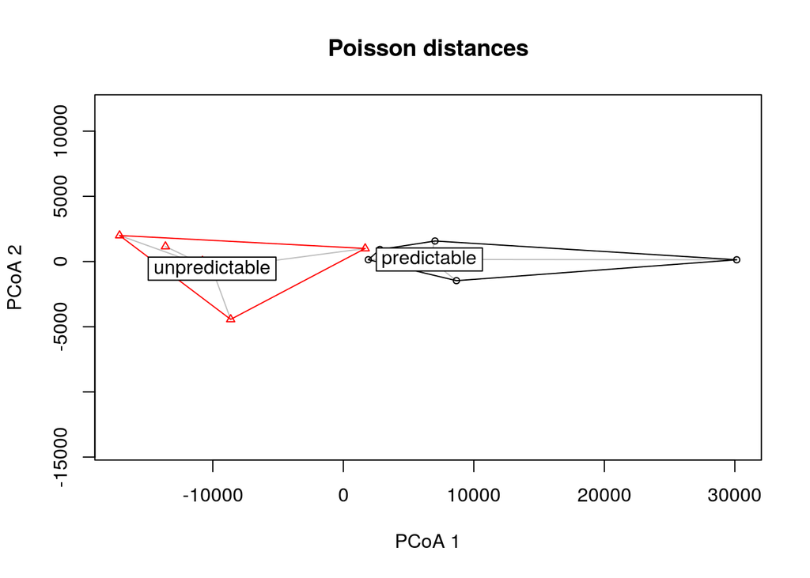

```r
plot(betadisper(poisd$dd, samples$regime), main='Poisson distances',
     sub='')
```

```r
png(filename = 'poisson.png')
  plot(betadisper(poisd$dd, samples$regime), sub='', main='')
dev.off()
```

Using the formal test, the difference in among-sample dispersion between regimes is not significant, even though the average distance to the centroid is lower in the regular than in the random environment. That was using the Poisson distance, which is appropriate for count data. Let’s try with a transformation of the count data that stabilizes the variance.

```r
rld <- rlog(dds, blind=TRUE)
sampleDist <- dist(t(assay(rld)))
permutest(betadisper(sampleDist, samples$regime))
```

```
##
## Permutation test for homogeneity of multivariate dispersions
## Permutation: free
## Number of permutations: 999
##
## Response: Distances
##           Df  Sum Sq Mean Sq      F N.Perm Pr(>F)
## Groups     1   37.01  37.006 0.1667    999  0.712
## Residuals 10 2219.67 221.967
```

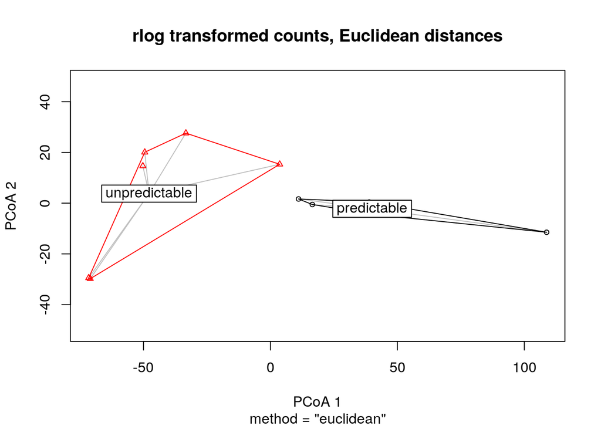

```r
plot(betadisper(sampleDist, samples$regime), main='rlog transformed counts, Euclidean distances')
```

# Conclusions

The unpredictable environment makes the expression of lowly expressed genes more variable, but it does not affect the genes expressed at high levels in the same way. As a result, the dispersion in the overall composition of RNA species among samples is not significantly higher among samples from the unpredictable environment.

# References

Anders, S., and W. Huber. 2010. “Differential Expression Analysis for Sequence Count Data.” *Genome Biology* 11: R106. https://doi.org/10.1186/gb-2010-11-10-r106.

Anderson, Marti J. 2006. “Distance-Based Tests for Homogeneity of Multivariate Dispersions.” *Biometrics* 62: 245–53. https://doi.org/10.1111/j.1541-0420.2005.00440.x.

McCarthy, D.J., Y. Chen, and G.K. Smyth. 2012. “Differential Expression Analysis of Multifactor Rna-Seq Experiments with Respect to Biological Variation.” *Nucleic Acids Research*, no. 10: 4288–97. https://doi.org/10.1093/nar/gks042.

Oksanen, Jari, F. Guillaume Blanchet, Michael Friendly, Roeland Kindt, Pierre Legendre, Dan McGlinn, Peter R. Minchin, et al. 2019. *Vegan: Community Ecology Package*. https://CRAN.R-project.org/package=vegan.

Witten, D. 2011. “Classification and Clustering of Sequencing Data Using a Poisson Model.” *The Annals of Applied Statistics* 5 (4): 2493–2518. https://doi.org/10.1214/11-AOAS493.